# Maddie Frick Assignment 4

MaddieFrick

11/19/2020

## b) Data and Analyses

In this analysis, the amount of trappings of hares throughout 1999 to 2012 were inconsistent per year, with the maximum amount of trappings in 1999 with a total of 126, and a minimum amount in 2010 with two trappings. The inconsistent counts of hares per year could have an effect on the data analyzed. The sex of the hare significantly had an effect on the hare weight (p = 0.007093), but with only a small effect size (Cohen’s d = -0.2904674). The hind foot length had a linear relationship with the hare weight with an R^2 value of 0.2988.

## c) Exploratory findings

### i) Annual juvenile hare trap counts

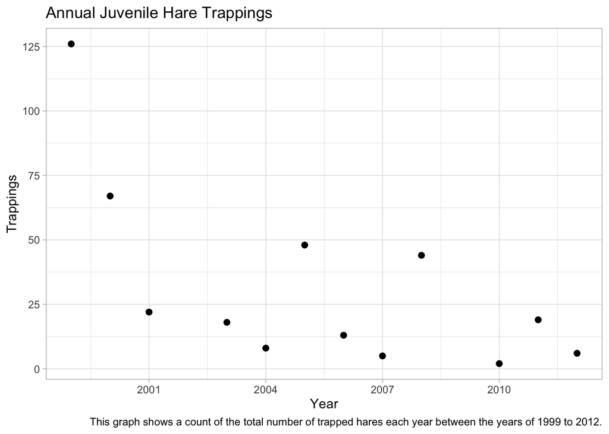

According to this graph, it looks like the amount of trappings per year decreased by 2001, and then fluctuated throughout the years of 2001-2012. The maximum number of trappings was in 1999 with a total of 126, and the minimum was in 2010 with two trappings. The mean number of trapped hares was 31.5 and the median was 18.5. There was a general trend of an initial decrease but not really any trend past 2001. I would suggest to do a more even number of hare trappings every year in order to standardize the juvenile hare population in future analyses. This would give a more accurate and consistent representation of the hare populations in every year, as a representative sample of 2 in 2010 will not cover the population very well.

### ii) Visualize juvenile hare weights

Create finalized data visualization in which juvenile weights by sex and site are compared.

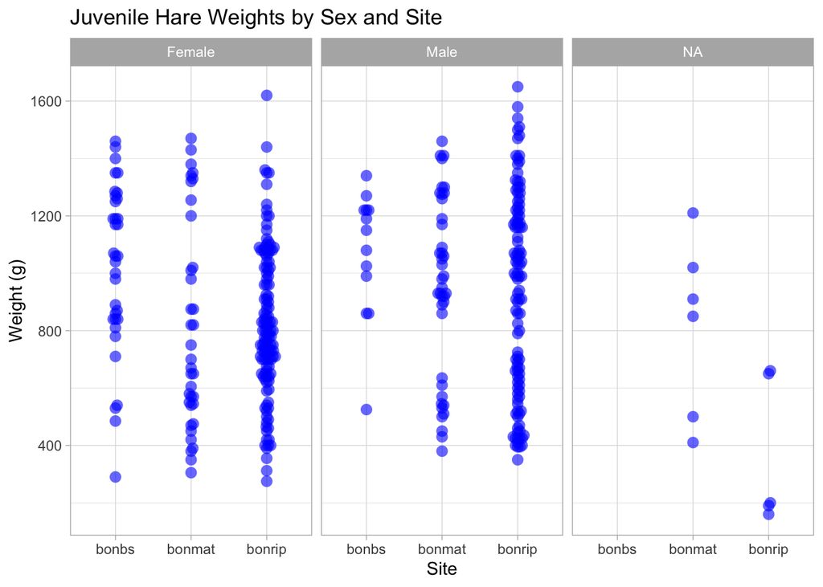

This beeswarm plot tells me that the sex and site do not make much of a difference on the hare weights. In the bonrip site, the male hares seem to be a little bit heavier than the females in bonrip, but otherwise the weights are widespread at all three sites for both the male and the female hares. I am showing the audience the straight data because the summary statistics do not always tell all of the information.

### iii) Juvenile weight comparison

This table shows the mean, median, standard deviation, and sample size of the juvenile male and female snowshoe hares included in this study.

| Sex | Mean | Median | Standard Deviation | Sample Size |
| --- | --- | --- | --- | --- |
| f | 855.3909 | 825 | 292.2526 | 197 |
| m | 945.8589 | 990 | 333.2151 | 163 |
| NA | 614.5455 | 650 | 357.5853 | 11 |

The actual difference in means of the male and female hares is 90.468. The mean body weight of the female hares was 855.39g and the males was 945.86g. I ran a two sample t test and cohen’s d test on female and male hare weights. There was a significant different in body mass, and a small effect size (Cohen’s d = -0.2904674). The resulting degrees of freedom was 325.02. The p value, the probability that we could have gotten sample means that are least as different as these if the null hypothesis (that they were pulled from populations with the same mean) was true is 0.007093. This means there is a .7% chance we could have gotten these from random chance if they were pulled from populations from the same mean, showing that sex probably has a significant effect on the weight of the hares. The cohen.d test showed us that the d estimate, the effect size, was -0.2904674, a small effect size of the sex of the hare on their weight.

### iv) Relationship between juvenile weight and hind foot length

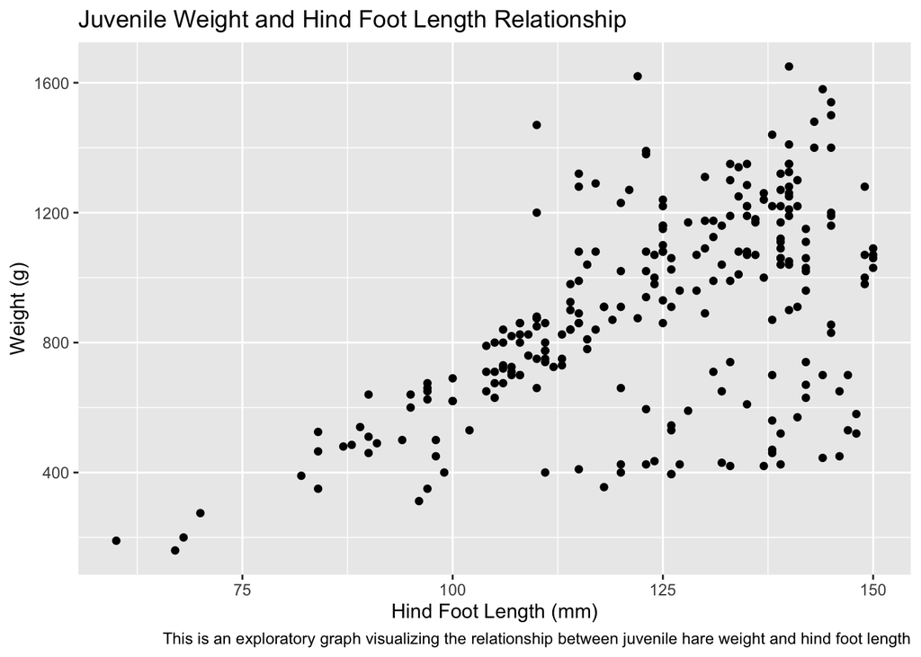

In this exploratory visualization, it looks like a linear relationship does make sense. The points are not exactly linear and the spread grows as the hind foot length increases, but the relationship is still somewhat linear, letting us use a linear model. Now I can model it using `lm()`.

[figure not shown]

Summary:

- ~30% of the variance in the weight was predictable from the hind foot length
- a significant regression model was found
- there was a positive correlation between hind foot length and weight